# Proyecto: Encuesta de Movilidad

## Fase II

### Integrantes:

- Luis Francisco Ortíz
- Daniel Mauricio Rojas
- Carlos Nicolas Hernández
- Ana Milena Rodríguez

## Preguntas guia

- ¿Cuáles son los patrones en las líneas de deseo de los bogotanos al movilizarse en la ciudad durante una semana promedio?
- ¿Cuáles son las Zonas de Análisis de Transporte más concentradas y demandadas por los bogotanos?
- ¿Como varían los patrones en las líneas de deseo según la hora y el medio de transporte utilizado?

### Distribuciones de Grados de ZATs

Interpretando la encuesta de movilidad como una gran red (grafo) donde los diferentes ZATs origen y destino, son los nodos y las conexiones entre ZATs, los arcos; es importante identificar qué tipo de red es y cómo está conectada, es decir tener una idea de cómo se realizaron esos viajes entre Zonas de Análisis de Transporte para identificar las líneas de deseo de los bogotanos.

Una aproximacón a este análisis consiste en derterminar los grados de cada ZAT(nodo) donde el 'grado' es el número de nodos adyacentes y conectados a este nodo.

Aquí cabe detallar que los ZATs son origen y destino de otros luego se van a identificar la cantidad de conexiones (Grados) por ZAT(nodo) cuando es origen (Grados de salida) y cuando es destino (Grados de entrada) y ver qué tipo de distribución tienen para identificar que tipo de Red Compleja es según su forma y dinámica.

- Del dataframe no se van a tener en cuenta los viajes donde el ZAT destino y el ZAT origen son iguales porque interesan los viajes entre diferentes ZATs.

A continuación trabajaremos con las bases de datos que consideramos pueden dar respuesta a nuestras preguntas.

### Importar la base principal

Cargamos los datos directamente del archivo pkl que se creó en la primera fase del proyecto.

```python
import pandas as pd
import pickle
import os
import numpy as np
import matplotlib.pyplot as plt
import networkx as nx
import seaborn as sns
import collections
import folium
pkl_file = open('viajes_df.pkl', 'rb')
viajes = pickle.load(pkl_file)
pkl_file.close()
```

```python
Viajes_Zats_OK=viajes[viajes['ZAT_ORIGEN']!=viajes['ZAT_DESTINO']]
Viajes_Zats_OK.shape
```

```
(99985, 39)
```

- Para cada ZAT origen identifico los nodos únicos con los que tienen conexión y estos son los Grados de Salida

```python
Viajes_Zats_out=Viajes_Zats_OK.groupby(['ZAT_ORIGEN']).ZAT_DESTINO.nunique().reset_index(name='Out_Conexion')
Viajes_Zats_out.shape
```

```
(880, 2)
```

```python
Viajes_Zats_out.rename(columns={'ZAT_ORIGEN': 'ZAT'}, inplace=True)
v_out= Viajes_Zats_out.sort_values('Out_Conexion', ascending=False)[['ZAT', 'Out_Conexion']]
v_out.head()
```

|  | ZAT | Out_Conexion |
| --- | --- | --- |
| 270 | 276 | 279 |
| 800 | 900 | 272 |
| 806 | 906 | 271 |
| 807 | 907 | 270 |
| 801 | 901 | 250 |

- Para cada ZAT destino identifico los nodos únicos con los que tienen conexión y estos son los Grados de Entrada

```python
Viajes_Zats_in=Viajes_Zats_OK.groupby(['ZAT_DESTINO']).ZAT_ORIGEN.nunique().reset_index(name='In_Conexion')
Viajes_Zats_in.shape
```

```
(880, 2)
```

```python
Viajes_Zats_in.rename(columns={'ZAT_DESTINO': 'ZAT'}, inplace=True)
v_in= Viajes_Zats_in.sort_values('In_Conexion', ascending=False)[['ZAT', 'In_Conexion']]
v_in.head()
```

|  | ZAT | In_Conexion |
| --- | --- | --- |
| 270 | 276 | 281 |
| 807 | 907 | 280 |
| 800 | 900 | 270 |
| 806 | 906 | 269 |
| 448 | 454 | 257 |

#### Graficar distribución de los grados

La distribución de grados de una red (grafo) se representa como el número de grados(conexiones) por cada nodo y se interpreta como la distribución de probabilidad de: $X$ nodo escogido tenga $Y$ conexiones (o vecinos).

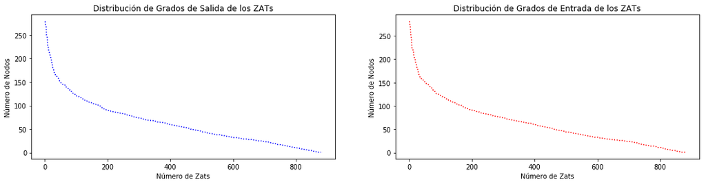

```python
f = plt.figure(figsize=(18,4))
ax = f.add_subplot(121)
ax2 = f.add_subplot(122)
x = np.linspace(1,880,880)
ax.plot(x, v_out.Out_Conexion, 'b:')
ax2.plot(x, v_in.In_Conexion, 'r:')

ax.set_xlabel('Número de Zats')
ax2.set_xlabel('Número de Zats')
ax2.set_ylabel('Número de Nodos')
ax.set_ylabel('Número de Nodos')

ax.set_title('Distribución de Grados de Salida de los ZATs')
ax2.set_title('Distribución de Grados de Entrada de los ZATs')

plt.show()
```

#### Interpretación y Análisis:

Se evidencia la existencia de nodos con grado muy alto y otros con grado muy bajo, y la distribucion obedece a una “ley de potencia” (Power-Law) que me indica que la conexion entre ZATs me forman una Red compleja de tipo libre de escala caracterizada por "centros" que son los nodos de más alto grado (gran número de nodos adyacentes), muy posiblemente asociados a puntos de trabajo o estudio como puntos de concentración o pueden ser puntos residenciales.

Estos nodos sirven con propósito específico en la red evidentemente por su grado, por lo que son seguidos por nodos con un grado medio y estos a su vez son seguidos por otros conformándose así secesivamente esta red.

La probabilidad de seleccionar aleaoriamente un nodo y que esté tenga un grado mayor a 200, es reducida, mientras que la propabilidad de seleccionar un nodo con un grado mayor a 75 es importante.

## Clustering de las zonas más concentradas

### Uso de K Means

Para determinar las zonas con mayor concentración de viajes se utilizará el algoritmo KMeans tomando como dato de agrupamiento el total de viajes desde cada uno de los ZAT Origen. Se tomarán 3 clusters para esta definición.

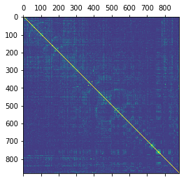

```python
zats_viajes = viajes.copy()
zats_viajes=zats_viajes.groupby(['ZAT_ORIGEN','ZAT_DESTINO'])['ZAT_ORIGEN'].size()
zats_viajes = zats_viajes.unstack()
zats_viajes['TOTAL_VIAJES']=zats_viajes.sum(axis=1)
zats_viajes = zats_viajes.fillna(0).reset_index()
zats_viajes.head()
plt.matshow(zats_viajes.corr())
```

```python
from sklearn.cluster import KMeans
from sklearn.decomposition import PCA

cluster = KMeans(n_clusters = 3)
zats_viajes['cluster'] = cluster.fit_predict(zats_viajes[zats_viajes.columns[:-1]])
```

```python
total_clusters = zats_viajes['cluster'].unique()

for each_cluster in total_clusters:
    print('Cluster '+str(each_cluster))
    print('Total registros '+str(len(zats_viajes[zats_viajes['cluster']==each_cluster])))
    print( 'Max viajes: ' + str(zats_viajes['TOTAL_VIAJES'][zats_viajes['cluster']==each_cluster].max()))
    print( 'Min viajes: ' + str(zats_viajes['TOTAL_VIAJES'][zats_viajes['cluster']==each_cluster].min()))
    print('\n')
```

```
Cluster 0
Total registros 864
Max viajes: 718.0
Min viajes: 1.0


Cluster 1
Total registros 13
Max viajes: 3553.0
Min viajes: 1667.0


Cluster 2
Total registros 3
Max viajes: 6450.0
Min viajes: 6029.0
```

De la ejecución del algoritmo se agruparon 3 clusters que tienen una gran variación en la cantidad de elementos. Se puede observar que el total de viajes salientes está concentrado en ZATS del cluster 2. Exploremos este clúster:

```python
zats_viajes[zats_viajes['cluster']==1]
```

[output not shown]

En este cluster se halla el ZAT 904 con gran cantidad de barrios lo que puede explicar la demanda de viajes salientes de esta zona.

### Gráfica de los clústers

Para visualizar la disperción de los puntos de cada clúster los graficamos en un plano 2d

```python
#separación en componentes para gráfica 2D
pca = PCA(n_components = 2)
cols = zats_viajes.columns[1:-1]
zats_viajes['x'] = pca.fit_transform(zats_viajes[cols])[:,0]
zats_viajes['y'] = pca.fit_transform(zats_viajes[cols])[:,1]
zats_clusters = zats_viajes[['ZAT_ORIGEN','cluster','x','y']]
zats_clusters.tail()
```

| ZAT_DESTINO | ZAT_ORIGEN | cluster | x | y |
| --- | --- | --- | --- | --- |
| 875 | 995 | 0 | -82.305490 | 0.702634 |
| 876 | 996 | 0 | -8.226701 | -0.625582 |
| 877 | 997 | 0 | -31.238521 | 0.847791 |
| 878 | 998 | 0 | -192.322953 | 3.069587 |
| 879 | 999 | 0 | -197.796914 | 3.257693 |

```python
import plotly.graph_objs as go
import plotly as ply
from plotly.offline import iplot

ply.offline.init_notebook_mode(connected=True)

trace0 = go.Scatter(x = zats_clusters[zats_clusters.cluster == 0]['x'],
                    y = zats_clusters[zats_clusters.cluster == 0]['y'],
                    name = 'Cluster 1',
                    mode = 'markers',
                    marker = dict(size = 10,
                                  color = 'rgba(15, 152, 152, 0.5)'))

trace1 = go.Scatter(x = zats_clusters[zats_clusters.cluster == 1]['x'],
                    y = zats_clusters[zats_clusters.cluster == 1]['y'],
                    name = 'Cluster 2',
                    mode = 'markers',
                    marker = dict(size = 10,
                                  color = 'rgba(122, 122, 12, 0.8)'))
trace2 = go.Scatter(x = zats_clusters[zats_clusters.cluster == 2]['x'],
                    y = zats_clusters[zats_clusters.cluster == 2]['y'],
                    name = 'Cluster 3',
                    mode = 'markers',
                    marker = dict(size = 10,
                                  color = 'rgba(230, 20, 30, 0.5)'))

data = [trace0,trace1,trace2]
```

```python
iplot(data)
```

[interactive chart not shown]

## Análisis sobre la hora y medio de transporte

Para análizar el comportamiento de los viajes haremos un recorrido por la distribución de las frecuencias de los viajes según la hora de inicio y fin y el medio de transporte

```python
hora_viajes = viajes.copy()
hora_viajes = hora_viajes[['HORA_INICIO','HORA_FIN','MEDIO_PREDOMINANTE']]
hora_viajes.dtypes
```

```
HORA_INICIO           object
HORA_FIN              object
MEDIO_PREDOMINANTE    object
dtype: object
```

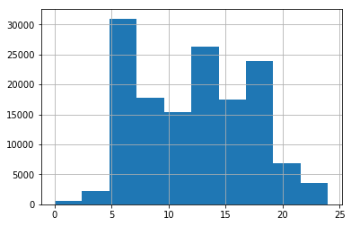

```python
hora_viajes['HORA_INICIO'] = pd.to_datetime(hora_viajes['HORA_INICIO']).dt.hour+ (1.0/60)*pd.to_datetime(hora_viajes['HORA_INICIO']).dt.minute
hora_viajes['HORA_INICIO'].hist()
```

```python
sel_rows = hora_viajes[hora_viajes['HORA_FIN'].str.startswith('24:')].index
hora_viajes = hora_viajes.drop(sel_rows, axis=0)
hora_viajes['HORA_FIN'] = pd.to_datetime(hora_viajes['HORA_FIN']).dt.hour+ (1.0/60)*pd.to_datetime(hora_viajes['HORA_FIN']).dt.minute
```

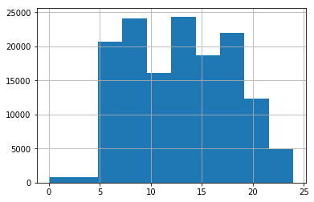

```python
hora_viajes['HORA_FIN'].hist()
```

```python
hora_viajes['DURACION'] = hora_viajes['HORA_FIN'] - hora_viajes['HORA_INICIO']
datos_negativos = hora_viajes[hora_viajes['DURACION']<0].index
hora_viajes = hora_viajes.drop(datos_negativos, axis=0)
```

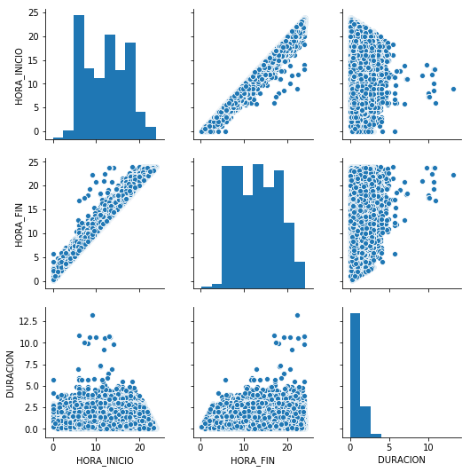

```python
sns.pairplot(hora_viajes)
plt.show()
```

## Análisis sobre medio de transporte

Usando pairplot se puede explorar el comportamiento de las horas de inicio y fin y la duración de los viajes según el medio de transporte

```
Distribución para medio:TPC-SITP
```

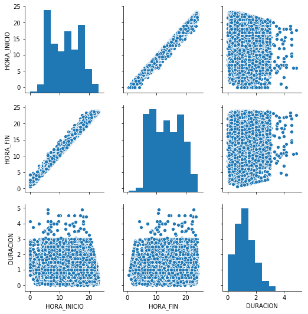

```
Distribución para medio:PEATON
```

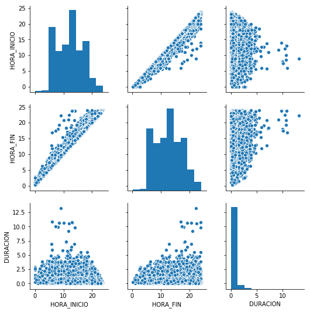

```
Distribución para medio:MOTO
```

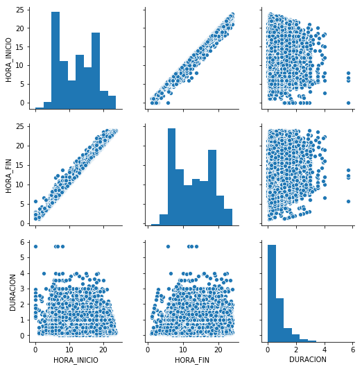

```
Distribución para medio:ESPECIAL
```

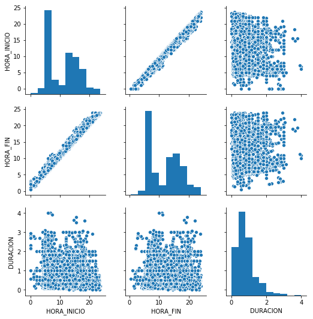

```
Distribución para medio:ALIMENTADOR
```

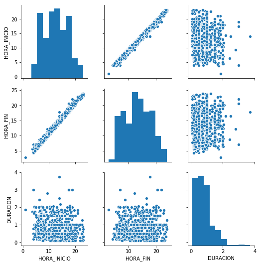

```
Distribución para medio:Transmilenio
```

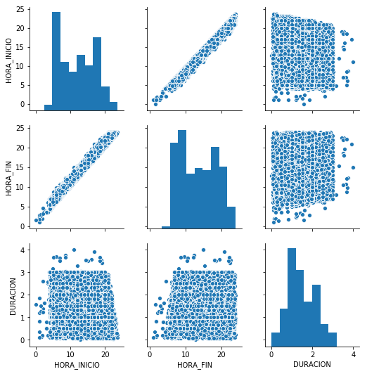

```
Distribución para medio:BICICLETA, BICICLETA CON MOTOR
```

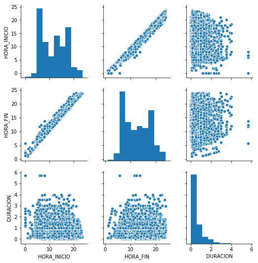

```
Distribución para medio:AUTO
```

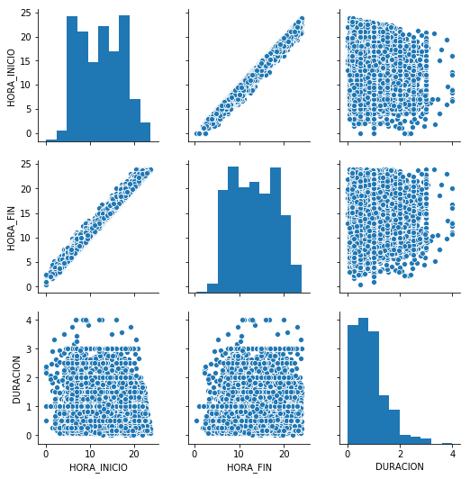

```
Distribución para medio:TAXI
```

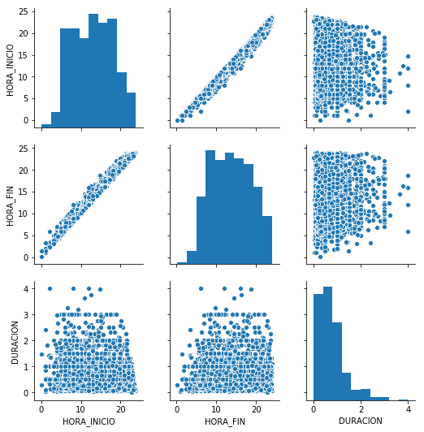

```
Distribución para medio:ILEGAL
```

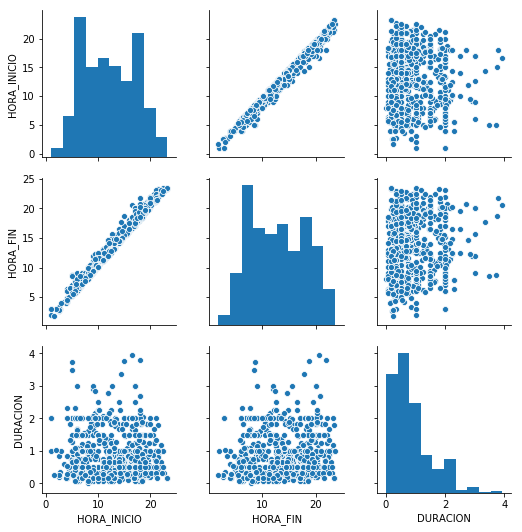

```
Distribución para medio:OTROS
```

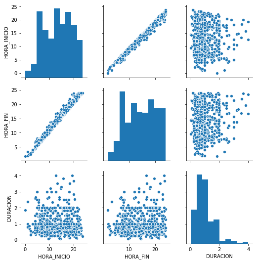

```
Distribución para medio:INTERMUNICIPAL
```

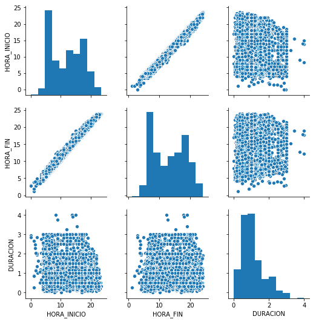

```python
medio_predominante = hora_viajes['MEDIO_PREDOMINANTE'].unique()
for cada_medio in medio_predominante:
    print('Distribución para medio:'+cada_medio)
    sns.pairplot(hora_viajes[hora_viajes['MEDIO_PREDOMINANTE'].str.contains(cada_medio)])
    plt.show()
    print('\n')
```

Se puede observar que la duración de los viajes presenta diferencias dependiendo del medio de transporte utilizado. Para el caso de Peaton presenta los viajes de mayor duración

## Distribución teórica de la duración de los viajes

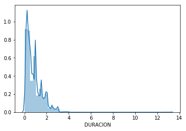

```python
sns.distplot(hora_viajes['DURACION'])
plt.show()
```

```python
from scipy.stats import lognorm, kstest
param = lognorm.fit( hora_viajes['DURACION'] )
print("\nParametros ajustados: "+str(param))

# Aplicar el test de Kolmogorov-Smirnov
D, p = kstest( hora_viajes['DURACION'], 'lognorm', args=param)
print("\nKolmogorov-Smirnov (D-stat, p-value): "+str((D, p)))
```

```
Parametros ajustados: (0.8479835268998422, -0.03564460629940902, 0.6301527216035582)

Kolmogorov-Smirnov (D-stat, p-value): (0.09368231642112557, 0.0)
```

## Ajuste a la distribución teórica

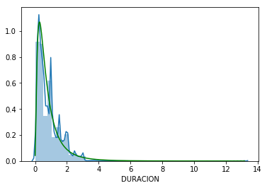

```python
sns.distplot( hora_viajes['DURACION'])

import numpy as np

x = np.linspace( hora_viajes['DURACION'].min() , hora_viajes['DURACION'].max(), 500)

y_pdf = lognorm.pdf(x, *param)
plt.plot(x, y_pdf, color='g')
plt.show()
```

## Visualización del grafo entre ZATs

A continuación, graficaremos los zats como nodos y sus conexiones como aristas que conectan cada nodo, con el fin de obtener una red compleja que muestre qué tan conectados están los zats.

```python
duracion_viajes = viajes.copy()
duracion_viajes['ZAT_ORIGEN-ZAT_DESTINO'] = duracion_viajes['ZAT_ORIGEN'].astype(str) + "-" + duracion_viajes['ZAT_DESTINO'].astype(str)
duracion_viajes2 = duracion_viajes[['ZAT_ORIGEN-ZAT_DESTINO']]
duracion_viajes2 = duracion_viajes2.groupby(['ZAT_ORIGEN-ZAT_DESTINO']).size().reset_index(name='Cant_viajes')
duracion_viajes2[duracion_viajes2['Cant_viajes']>1000]
```

|  | ZAT_ORIGEN-ZAT_DESTINO | Cant_viajes |
| --- | --- | --- |
| 50738 | 900-900 | 1768 |
| 50992 | 901-901 | 2366 |
| 51170 | 902-902 | 2319 |
| 51299 | 903-903 | 1627 |
| 51515 | 904-904 | 5264 |
| 51670 | 905-905 | 1375 |
| 51930 | 906-906 | 1983 |
| 52205 | 907-907 | 4592 |
| 52346 | 908-908 | 1162 |
| 52514 | 909-909 | 1582 |
| 52752 | 910-910 | 4905 |
| 52862 | 911-911 | 1552 |
| 52996 | 912-912 | 2373 |
| 53103 | 913-913 | 1898 |
| 53285 | 914-914 | 1914 |
| 53493 | 915-915 | 1291 |

```python
duracion_viajes2['Source'], duracion_viajes2['Target'] = duracion_viajes2['ZAT_ORIGEN-ZAT_DESTINO'].str.split('-', 1).str
duracion_viajes2.head()
```

|  | ZAT_ORIGEN-ZAT_DESTINO | Cant_viajes | Source | Target |
| --- | --- | --- | --- | --- |
| 0 | 1-103 | 1 | 1 | 103 |
| 1 | 1-118 | 1 | 1 | 118 |
| 2 | 1-321 | 1 | 1 | 321 |
| 3 | 1-33 | 1 | 1 | 33 |
| 4 | 1-356 | 1 | 1 | 356 |

```python
red = duracion_viajes2[['Source', 'Target', 'Cant_viajes']]
```

```python
edges = red[['Source', 'Target']].values
```

Se utiliza la librería networkx para crear la red de conexiones entre ZATs, encontrando el número de nodos y sus conexiones

```python
G = nx.from_edgelist(edges)
len(G.nodes()), len(G.edges())
```

```
(880, 30603)
```

```
Text(0.5,1,'Conexiones entre ZATs')
```

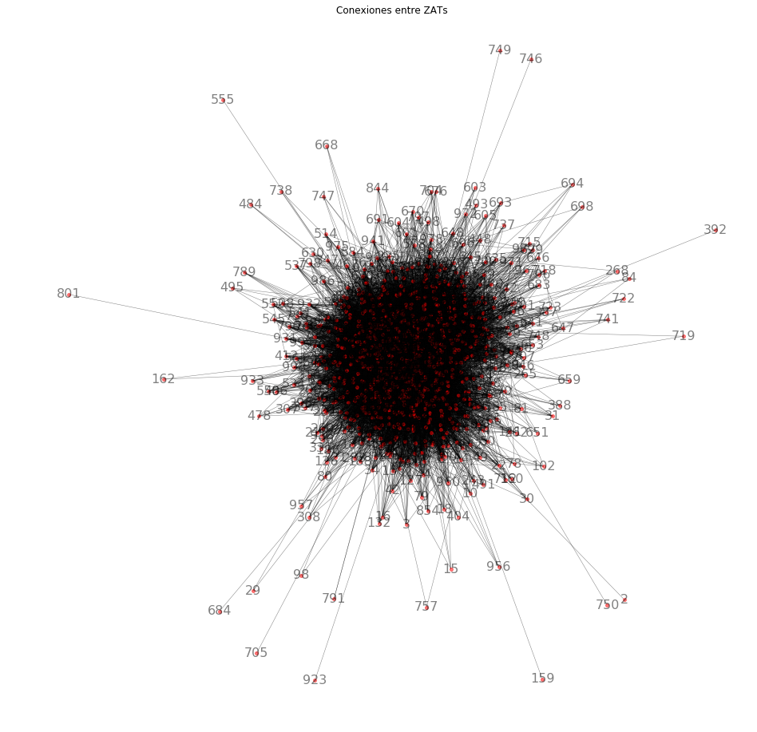

```python
fig, ax = plt.subplots(1, 1, figsize=(16, 16))
nx.draw_networkx(G, ax=ax, node_size=15,
                 font_size=16, alpha=.5,
                 width=.5)
ax.set_axis_off()
plt.title("Conexiones entre ZATs")
```

En una primera impresión, se puede ver que el grafo tiene una alta densidad de conexiones, lo que haremos a continuación, es trabajar en visualizar los nodos con mayor frecuencia de viajes.

## Sacamos aquellas conexiones que se den entre un mismo ZAT

Esto dado que un zat que esté conectado con si mismo no aporta a la visualización.

```python
Viajes_Zats_Group=viajes.groupby(['ZAT_ORIGEN','ZAT_DESTINO', 'longitude_o', 'latitude_o', 'longitude_d', 'latitude_d']).size().reset_index(name='CANT_VIAJES')
Viajes_Zats_Group = Viajes_Zats_Group[Viajes_Zats_Group['ZAT_ORIGEN'] != Viajes_Zats_Group['ZAT_DESTINO']]
dff = Viajes_Zats_Group
```

```python
dff['CANT_VIAJES'].mean()
```

```
1.7901776122609754
```

Promedio de cantidad de viajes existentes: 1.7901

```python
dff['Stand_V'] = (dff['CANT_VIAJES']/sum(dff['CANT_VIAJES']))*100
dff.head()
```

|  | ZAT_ORIGEN | ZAT_DESTINO | longitude_o | latitude_o | longitude_d | latitude_d | CANT_VIAJES | Stand_V |
| --- | --- | --- | --- | --- | --- | --- | --- | --- |
| 0 | 1 | 33 | 4.799929 | -74.070455 | 4.755771 | -74.087636 | 1 | 0.001 |
| 1 | 1 | 36 | 4.799929 | -74.070455 | 4.756306 | -74.112735 | 3 | 0.003 |
| 2 | 1 | 103 | 4.799929 | -74.070455 | 4.720984 | -74.094219 | 1 | 0.001 |
| 3 | 1 | 118 | 4.799929 | -74.070455 | 4.740484 | -74.128069 | 1 | 0.001 |
| 4 | 1 | 321 | 4.799929 | -74.070455 | 4.660963 | -74.120802 | 1 | 0.001 |

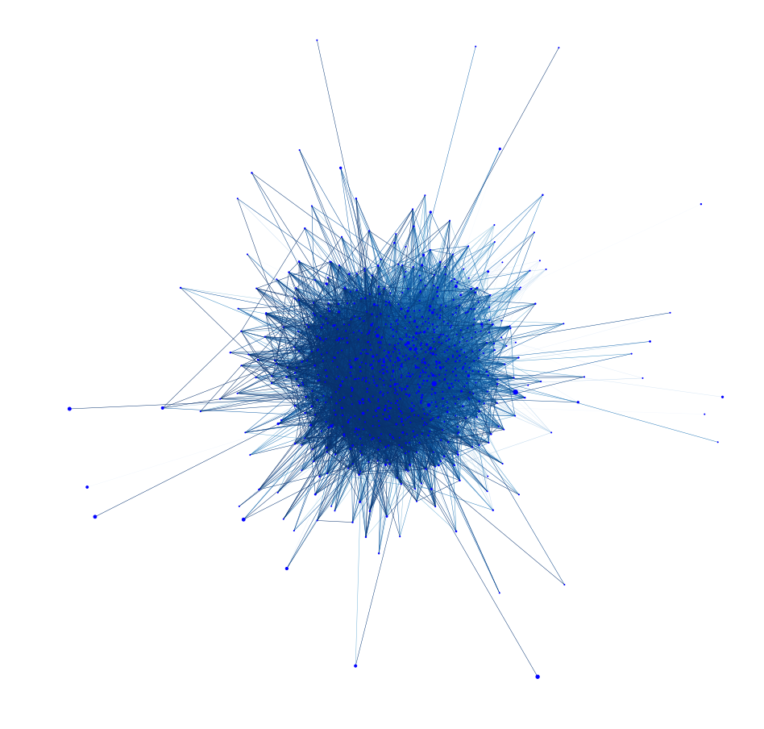

```python
node_sizes = [ i for i in dff['CANT_VIAJES']]
M = G.number_of_edges()
pos = nx.layout.spring_layout(G)
edge_colors = range(2, M + 2)
plt.subplots(1, 1, figsize=(16, 16))
nodes = nx.draw_networkx_nodes(G, pos, node_size=node_sizes, node_color='blue')
edges = nx.draw_networkx_edges(G, pos, node_size=node_sizes, arrowstyle='->',
                               arrowsize=10, edge_color=edge_colors,
                               edge_cmap=plt.cm.Blues, width=.5)

ax = plt.gca()
ax.set_axis_off()
plt.show()
```

A continuación, tomaremos aquellas conexiones que superan el 0.02% del total de viajes existentes en la base de datos para acotar el número de nodos en la red.

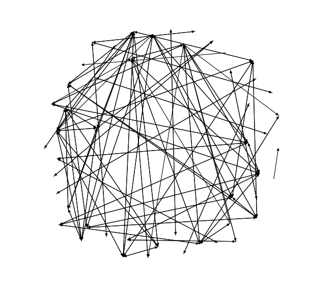

```python
dff = pd.DataFrame(dff)
dff.dtypes
df = dff[dff['Stand_V']>=0.02]
G=nx.from_pandas_edgelist(df, 'ZAT_ORIGEN', 'ZAT_DESTINO', create_using=nx.DiGraph())
pos = nx.spring_layout(G,k=10.15,iterations=20)
plt.subplots(1, 1, figsize=(10, 10))
nx.draw_networkx_edges(G, pos, with_labels=True, node_color='skyblue',
        node_size=3, width=1.1, edge_cmap=plt.cm.Blues)
ax = plt.gca()
ax.set_axis_off()
plt.show()
```

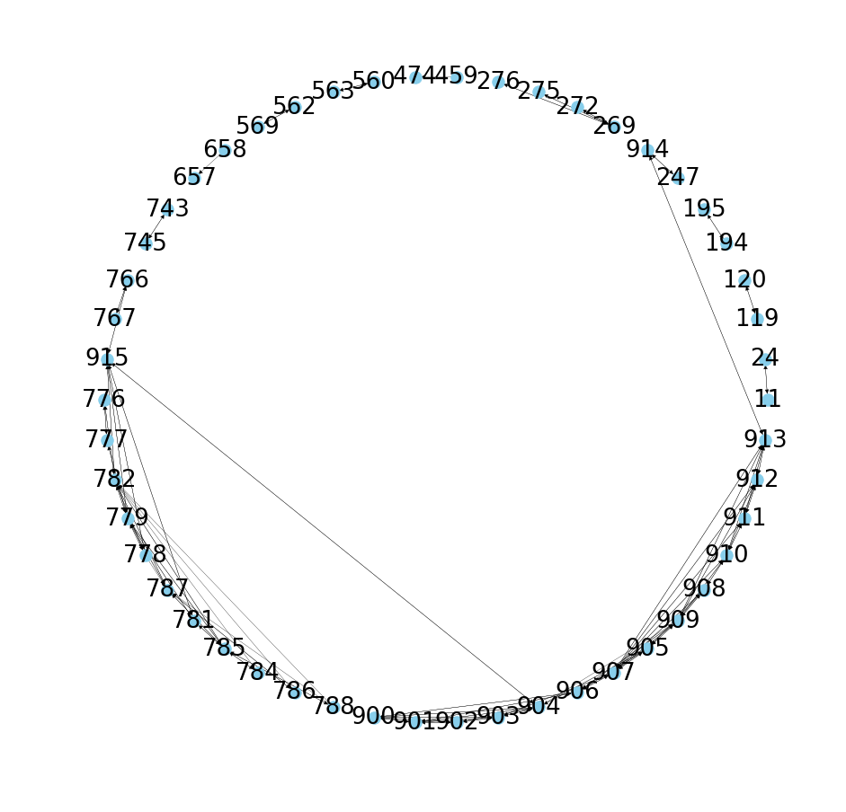

```python
G = nx.from_pandas_edgelist(df, 'ZAT_ORIGEN', 'ZAT_DESTINO', create_using=nx.DiGraph())
plt.subplots(1, 1, figsize=(16, 16))
nx.draw_circular(G, node_color='skyblue', node_size=180, width=.3, cmap=plt.cm.Blues,
        with_labels=True,font_size=26)
plt.show()
```

Se puede ver que de manera circular el grafo no se encuentra completamente conectado (no es una red distribuida) y existen grupos de nodos conectados uno al lado del otro.

A continuación, se graficará los puntos por su georreferenciación para conocer qué puntos de la ciudad hacen referencia.

```python
locations = df[['longitude_o', 'latitude_o']]
locationlist = locations.values.tolist()
dd = pd.DataFrame(df[['ZAT_ORIGEN', 'longitude_o', 'latitude_o']])
dd = dd.drop_duplicates('ZAT_ORIGEN', keep='first')
dd['new'] = list(zip(dd['longitude_o'], dd['latitude_o']))
dd = dd[['ZAT_ORIGEN', 'new']]
da = dd.set_index('ZAT_ORIGEN').to_dict()
da = da['new']
dap = pd.DataFrame(df[['ZAT_DESTINO', 'longitude_d', 'latitude_d']])
dap = dap.drop_duplicates('ZAT_DESTINO', keep='first')
dap['new'] = list(zip(dap['longitude_d'], dap['latitude_d']))
dap = dap[['ZAT_DESTINO', 'new']]
daa = dap.set_index('ZAT_DESTINO').to_dict()
daa = daa['new']
```

Si un ZAT no está en ZAT_ORIGEN pero si está en ZAT_DESTINO debe pintarlo de color rojo

```python
map = folium.Map(location=locationlist[1], zoom_start=10)
for k,v in da.items():
    folium.Marker(v,  popup=str(k), icon=folium.Icon(color='black', icon='info-sign')).add_to(map)
for k,v in daa.items():
    if k in da:
        next
    else:
        folium.Marker(v,  popup=str(k), icon=folium.Icon(color='red', icon='info-sign')).add_to(map)
map
```

[interactive chart not shown]

Por último, se grafica las conexiones entre los ZATs para encontrar patrones de viajes. Es necesario recordar que los nodos que son de color negro es porque están tanto en ORIGEN como DESITNO y si está de otro color (rojo), es porque solo se encuentra como ZAT destino.

```python
dp = pd.DataFrame(df[['ZAT_ORIGEN','ZAT_DESTINO', 'longitude_o', 'latitude_o', 'longitude_d','latitude_d']])
dp = dp.drop_duplicates(['ZAT_ORIGEN', 'ZAT_DESTINO'], keep='first')
dp['new1'] = list(zip(dp['ZAT_ORIGEN'], dp['ZAT_DESTINO']))
dp['or'] = list(zip(dp['longitude_o'], dp['latitude_o']))
dp['de'] = list(zip(dp['longitude_d'], dp['latitude_d']))
dp['new'] = list(zip(dp['or'], dp['de']))
ded = dp[['new1', 'new']]
ded.head()
da1 = ded.set_index('new1').to_dict()
da1 = da1['new']
```

```python
map = folium.Map(location=locationlist[7], zoom_start=10)
for k,v in da.items():
    folium.Marker(v,  popup=str(k), icon=folium.Icon(color='black', icon='info-sign')).add_to(map)
for k,v in daa.items():
    if k in da:
        next
    else:
        folium.Marker(v,  popup=str(k), icon=folium.Icon(color='red', icon='info-sign')).add_to(map)
for k,v in da1.items():
    folium.PolyLine((v[0],v[1]), color="blue",weight=3,fill_opacity=0.8).add_to(map)
map
```

[interactive chart not shown]

Se puede evidenciar que existen grupos de nodos que por su ubicación geográfica están conectados uno con otro lo que nos lleva a pensar que las personas se movilizan en un día promedio solo en esas ubicaciones. Adicionalmente, para la fase final proporcionaremos filtros por medio de transporte y por día (si es habil o no) de manera interactiva, lo que permitirá visualizar el total de puntos conectados y su variación mientras cambia la hora de inicio y la hora fin de los trayectos.

### Métricas de grafos

- Betweennes centrality - Número de veces que un nodo actúa como puente a lo largo del camino más corto entre un par de nodos
- Closeness centrality - Promedio de distancia más corta desde un nodo hacia todos los demás
- Eigenvector centrality - Medida de influencia de un nodo en toda la red
- Degree centrality - Número de enlaces que posee un nodo con los demás

A continuación determinamos las métricas de los grafos para entender la importancia de los nodos en el conjunto de la red. De esta manera identificamos nodos críticos que pueden ejercer gran inluencia en la red.

```python
edges = red[['Source', 'Target']].values
G = nx.from_edgelist(edges)
# Betweenness centrality
bet_cen = nx.betweenness_centrality(G)
# Closeness centrality
clo_cen = nx.closeness_centrality(G)
# Eigenvector centrality
eig_cen = nx.eigenvector_centrality(G)
# Degree centrality
deg_cen = nx.degree_centrality(G)
```

```python
bet = pd.Series(bet_cen).to_frame()
bet = bet.sort_values(0,ascending=False)
bet[0:9]
```

|  | 0 |
| --- | --- |
| 276 | 0.018212 |
| 906 | 0.016092 |
| 907 | 0.015946 |
| 454 | 0.015450 |
| 275 | 0.014412 |
| 255 | 0.012731 |
| 900 | 0.011861 |
| 901 | 0.011795 |
| 363 | 0.010558 |

```python
clo = pd.Series(clo_cen).to_frame()
clo = clo.sort_values(0,ascending=False)
clo[0:9]
```

|  | 0 |
| --- | --- |
| 276 | 0.602467 |
| 907 | 0.591123 |
| 900 | 0.589933 |
| 906 | 0.589142 |
| 454 | 0.589142 |
| 275 | 0.588353 |
| 255 | 0.587567 |
| 901 | 0.579815 |
| 354 | 0.577909 |

```python
eig = pd.Series(eig_cen).to_frame()
eig = clo.sort_values(0,ascending=False)
eig[0:9]
```

|  | 0 |
| --- | --- |
| 276 | 0.602467 |
| 907 | 0.591123 |
| 900 | 0.589933 |
| 906 | 0.589142 |
| 454 | 0.589142 |
| 275 | 0.588353 |
| 255 | 0.587567 |
| 901 | 0.579815 |
| 354 | 0.577909 |

```python
deg = pd.Series(deg_cen).to_frame()
deg = deg.sort_values(0,ascending=False)
deg[0:9]
```

|  | 0 |
| --- | --- |
| 276 | 0.352673 |
| 907 | 0.325370 |
| 906 | 0.324232 |
| 900 | 0.323094 |
| 454 | 0.315131 |
| 255 | 0.313993 |
| 275 | 0.312856 |
| 901 | 0.292378 |
| 363 | 0.286689 |

Dadas las métricas anteriores, identificamos nodos críticos que tienen un peso importante dentro de la red. De esta manera podemos priorizar el análisis sobre estos nodos en la Fase III del proyecto para entender su influencia y rol dentro de la red.